# Temporal Autocorrelation

Let’s check the values:

```r
acf1
```

```
## [1] 1.0000000 0.8488162 0.8283975 0.8161328 0.7990073
```

```r
acf5
```

```
## [1] 1.0000000 0.7253348 0.6275806 0.5589635 0.4974726
```

ACF values bear this out. Subsetting has helped.

Let’s see if we condition our RDA on time, as per the next best model:

```r
rda6 <- rda(DL_cent_10 ~ low_freq_ACI + low_freq_H + low_freq_M +
                  low_freq_BI + high_freq_ACI + high_freq_BI + high_freq_H + Condition(time_cont),
                data=metadata_10,
                scale=FALSE,
                na.action=na.omit)
```

Check TA for a few Y variables

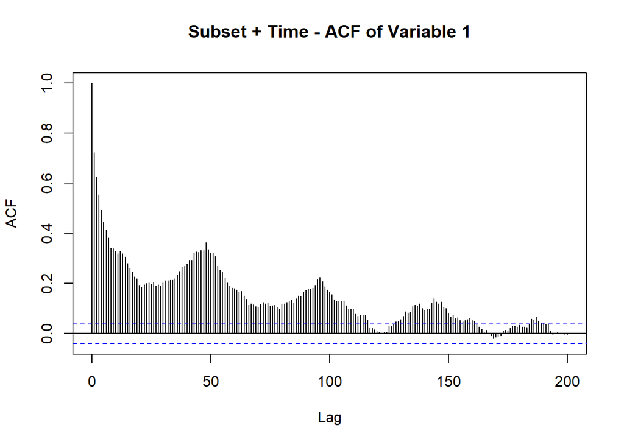

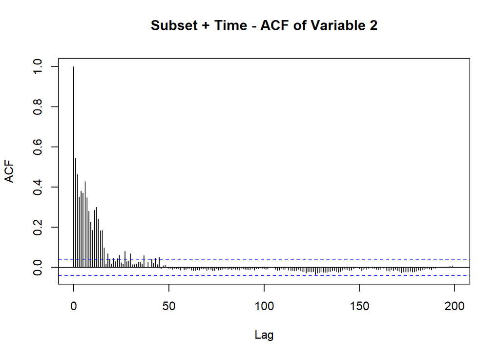

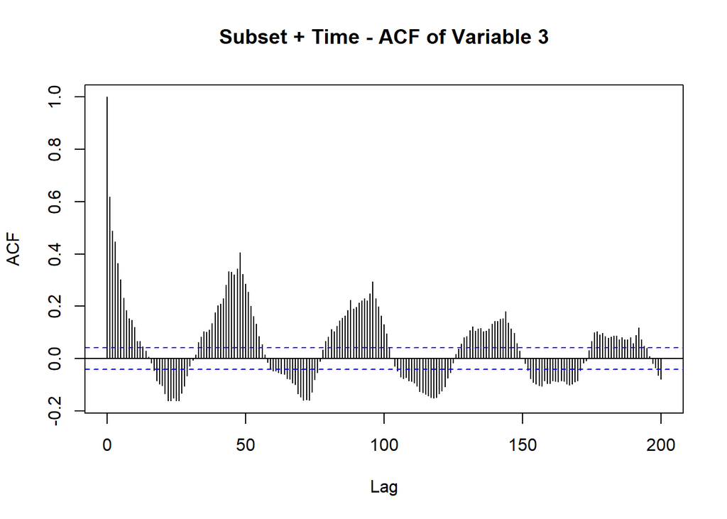

```r
res_rda6 <- residuals(rda6)

lapply(1:3, function(i) acf(res_rda6[, i], lag.max = 200, main = paste("Subset + Time - ACF of Variable", i)))
```

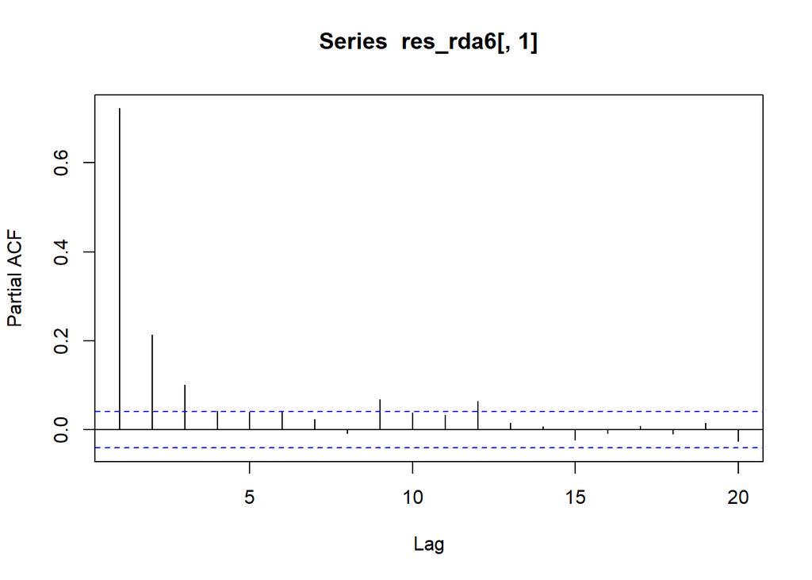

```r
pacf(res_rda6[,1], lag.max = 20)
```

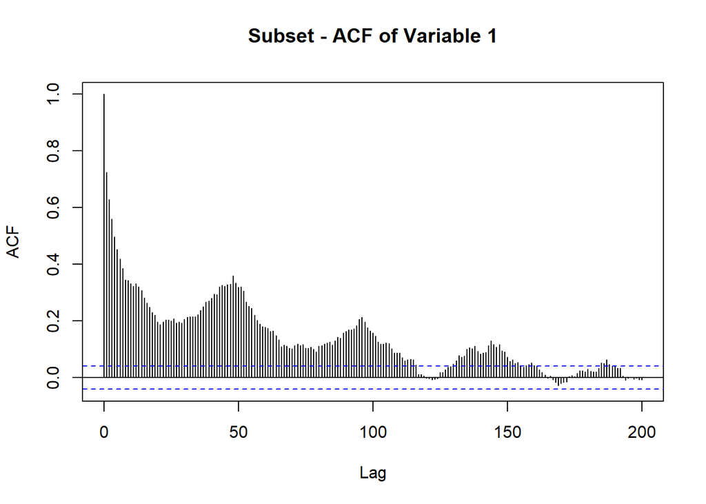

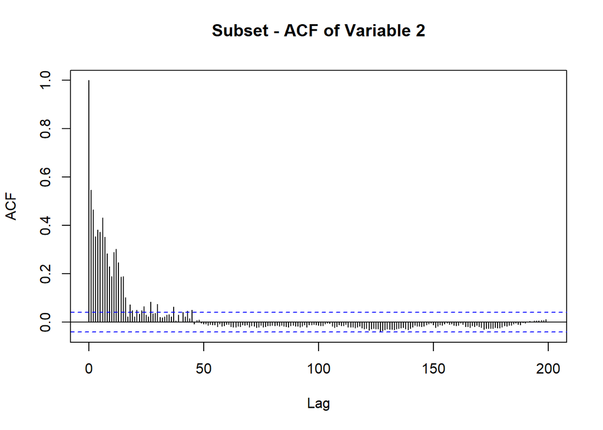

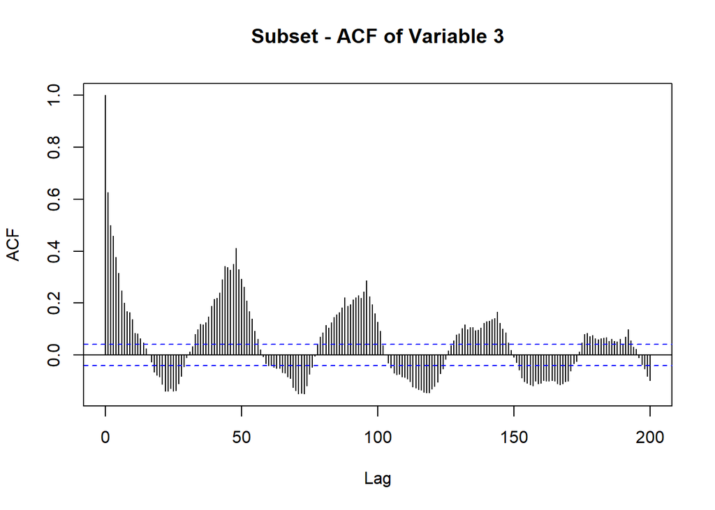

```r
acf_values <- acf(res_rda6, plot = FALSE)
acf6 <- acf_values$acf[1:5]

# Compare to subset without time:
lapply(1:3, function(i) acf(res_rda5[, i], lag.max = 200, main = paste("Subset - ACF of Variable", i)))
```

```r
# Compare to the full data:
lapply(1:3, function(i) acf(res_rda1[, i], lag.max = 200, main = paste("Full - ACF of Variable", i)))
```

[output not shown]

Very small improvement for 2 out of 3 variables (var 2 seems to get marginally worse modelling with time!).

Check the numbers:

```r
acf1
```

```
## [1] 1.0000000 0.8488162 0.8283975 0.8161328 0.7990073
```

```r
acf5
```

```
## [1] 1.0000000 0.7253348 0.6275806 0.5589635 0.4974726
```

```r
acf6
```

```
## [1] 1.0000000 0.7223369 0.6238552 0.5545755 0.4925086
```

Very marginal improvement.

**In Summary: Subsetting helps but time has not been modelled effectively.**

### 1min in 60 subsample

Let’s go even more extreme; 1 recording per hour Let’s go extreme to see if it helps:

```r
metadata_20 <- metadata_sd_cat %>%
  filter(row_number() %% 20 == 1) %>%
  rownames_to_column(var="Filename") %>%
  arrange(Filename)

DL_cent_20 <- metadata_20 %>%
  select(Filename) %>%
  left_join(
    DL_cent %>% rownames_to_column(var = "Filename"),
    by = "Filename"
  )

identical(metadata_20[['Filename']], DL_cent_20[['Filename']])
```

```
## [1] TRUE
```

```r
DL_cent_20 <- DL_cent_20 %>%
  column_to_rownames(var = "Filename")
```

OK, lets try the basic model:

```r
rda7 <- rda(DL_cent_20 ~ low_freq_ACI + low_freq_H + low_freq_M +
                  low_freq_BI + high_freq_ACI + high_freq_BI + high_freq_H,
                data=metadata_20,
                scale=FALSE,
                na.action=na.omit)
```

Check TA for a few Y variables

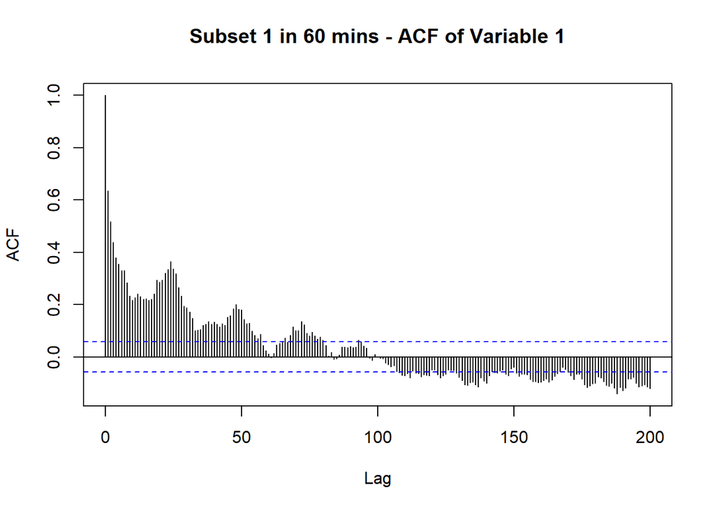

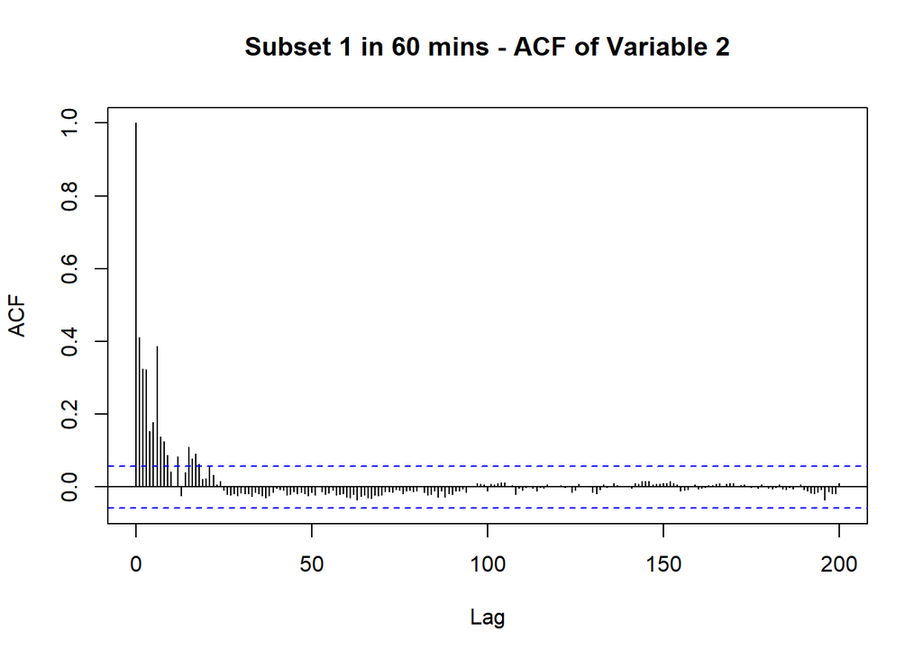

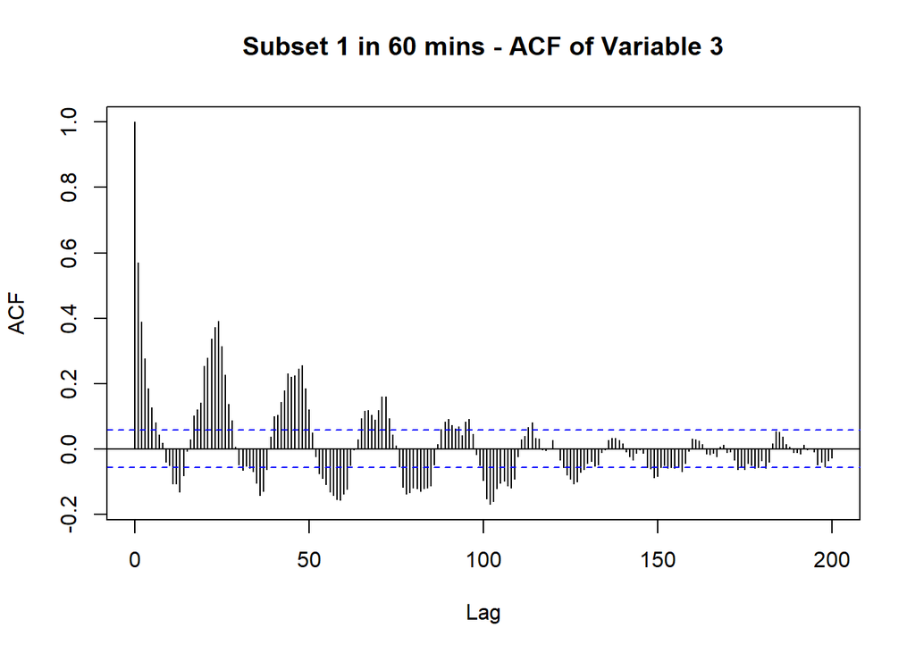

```r
res_rda7 <- residuals(rda7)

lapply(1:3, function(i) acf(res_rda7[, i], lag.max = 200, main = paste("Subset 1 in 60 mins - ACF of Variable", i)))
```

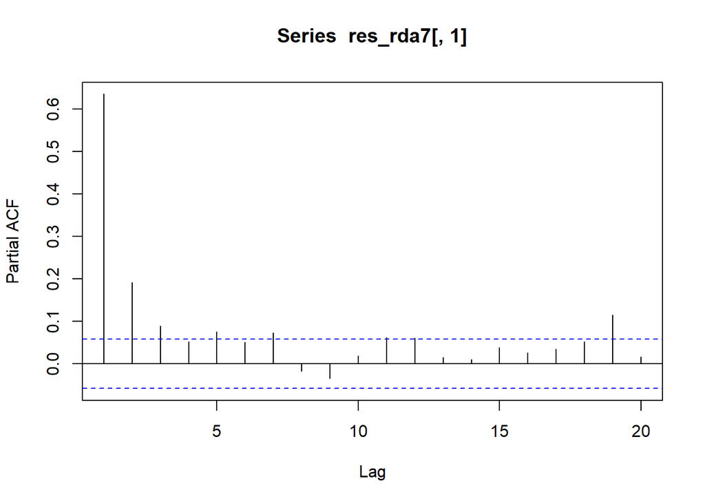

```r
pacf(res_rda7[,1], lag.max = 20)
```

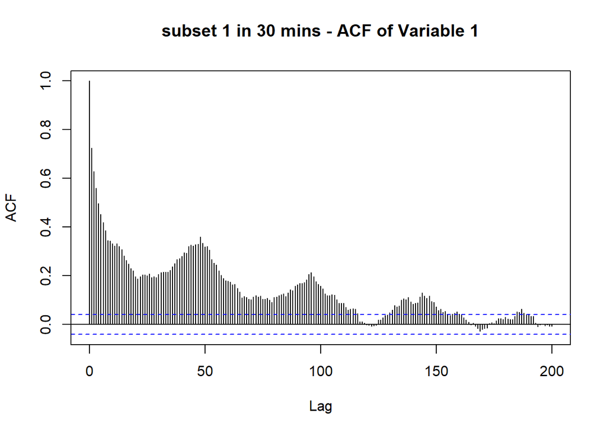

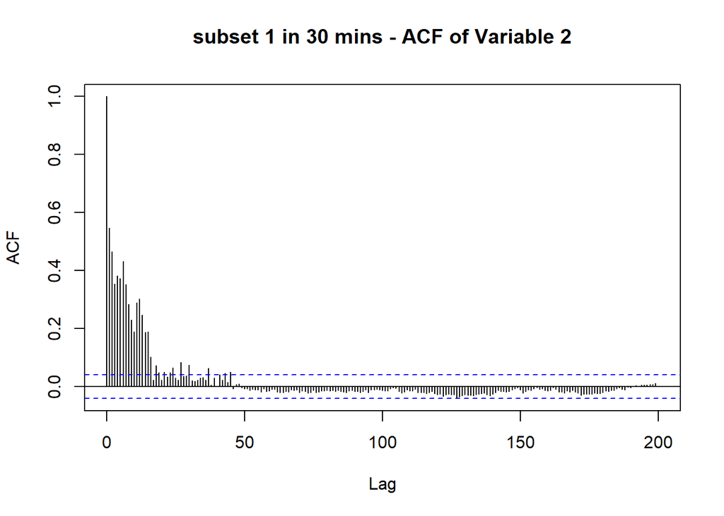

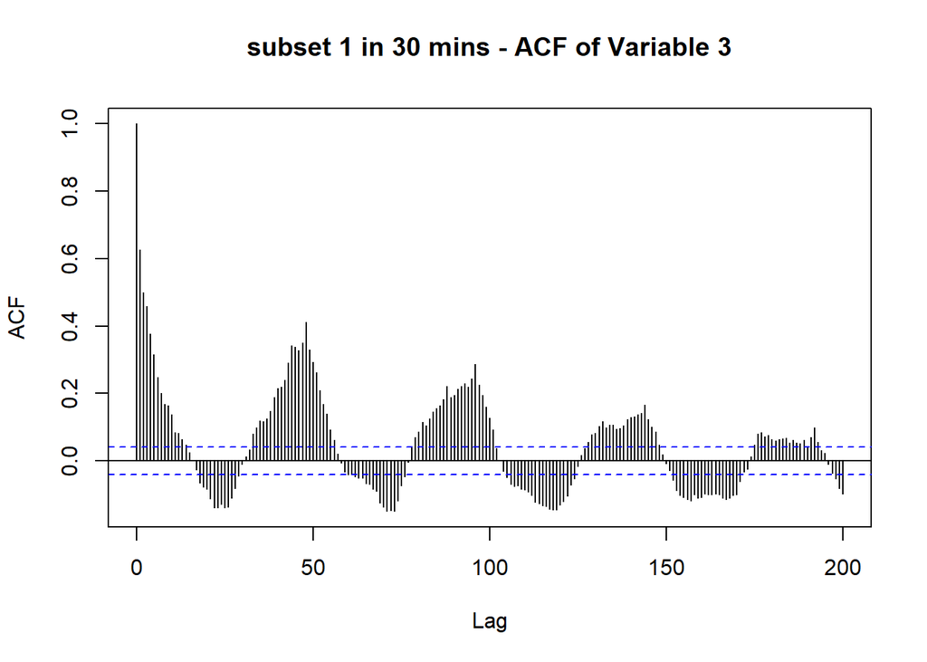

```r
acf_values <- acf(res_rda7, plot = FALSE)
acf7 <- acf_values$acf[1:5]

# Compare to the 1 in 30 mins:
lapply(1:3, function(i) acf(res_rda5[, i], lag.max = 200, main = paste("subset 1 in 30 mins - ACF of Variable", i)))
```

```r
# Compare to the full data:
lapply(1:3, function(i) acf(res_rda1[, i], lag.max = 200, main = paste("Full - ACF of Variable", i)))
```

[output not shown]

Does look better. Numbers:

```r
acf1
```

```
## [1] 1.0000000 0.8488162 0.8283975 0.8161328 0.7990073
```

```r
acf5
```

```
## [1] 1.0000000 0.7253348 0.6275806 0.5589635 0.4974726
```

```r
acf7
```

```
## [1] 1.0000000 0.6348193 0.5173771 0.4383038 0.3793545
```

A big improvement. **So subsetting may be helpful**

**Question: should I be comparing the same number of lags (e.g first 100) or the *time period* those lags represent (e.g. 10 days)? Seems to effect the analysis:**

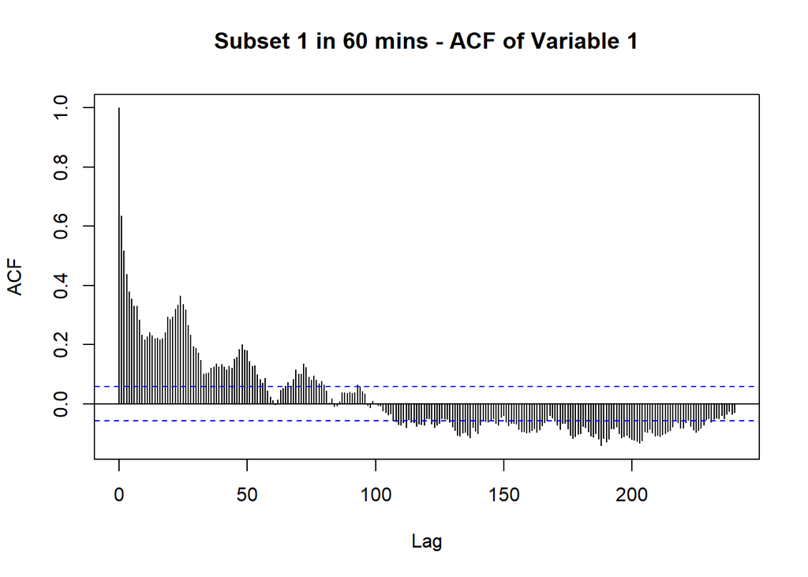

```r
res_rda7 <- residuals(rda7)

# lag.max set to 10 days
lapply(1, function(i) acf(res_rda7[, i], lag.max = 240, main = paste("Subset 1 in 60 mins - ACF of Variable", i)))
```

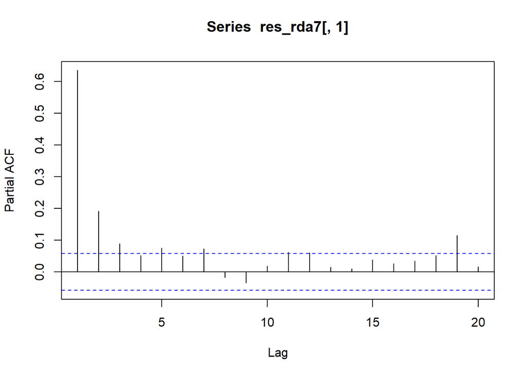

```r
pacf(res_rda7[,1], lag.max = 20)
```

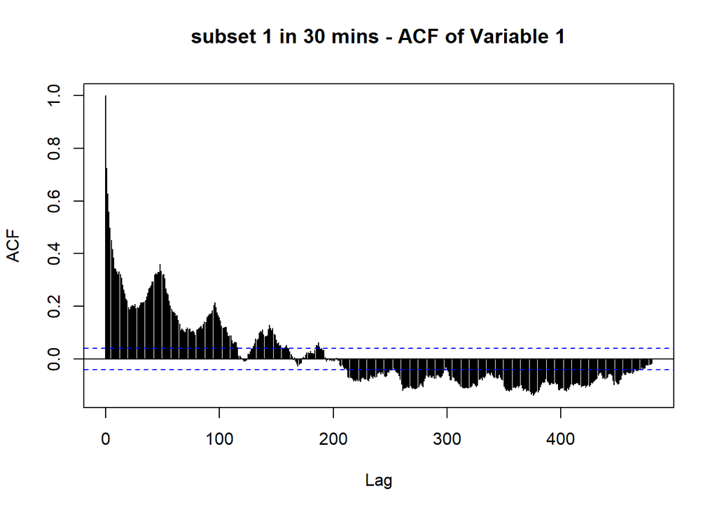

```r
acf_values <- acf(res_rda7, plot = FALSE)
acf7 <- acf_values$acf[1:5]

# To compare over the same time period vary lag.max accordingly
# Compare to the 1 in 30 mins:
lapply(1, function(i) acf(res_rda5[, i], lag.max = 480, main = paste("subset 1 in 30 mins - ACF of Variable", i)))
```

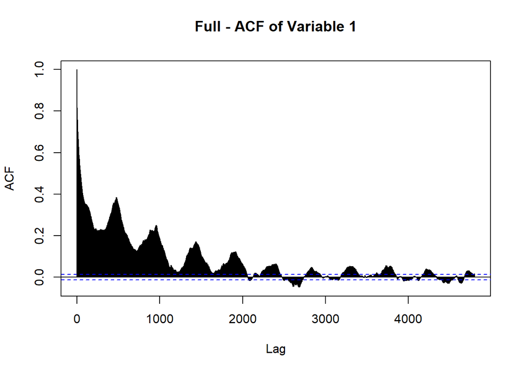

```r
# Compare to the full data:
lapply(1, function(i) acf(res_rda1[, i], lag.max = 4800, main = paste("Full - ACF of Variable", i)))
```

In this case the structure of the temporal dependence appears identical, just with fewer obs. Hmm…

## 3. **Using Auto regressive Models**

**The *vegan()* package lacks the functionality to implement RDA with autocorrelated variables. Luckily, RDA can be thought of as a PCA on the fitted values of a regression model. So if we can find a regression model that accounts for the TA, we can iterate over the response variables and perform a PCA on the fitted values.**

We can use Generalized Least Squares (GLS) as it doesn’t assume independent residuals. Let’s try for the first Deep Learning variable and the subset that had the least TA (1 in 60 mins):

```r
# First create dataframes for the subset

Y <- DL_cent_20[2]
Y <- Y %>% rownames_to_column(var = "Filename")
Y <- Y %>% rename(feat_1 = `1`)

X <- metadata_20

df <- inner_join(X, Y, by ="Filename")
```

Now we can specify a couple of models and compare:

- mod 1 = subset (1 in 60), no autoregressive term
- mod 2 = subset (1 in 60) + 1st order autoregressive term

```r
library(nlme)

# No autoregressive term:
mod1 <- gls(feat_1 ~ low_freq_ACI + low_freq_H + low_freq_M +
                  low_freq_BI + high_freq_ACI + high_freq_BI + high_freq_H,
            data = df)

# First order AR term:
mod2 <- gls(feat_1 ~ low_freq_ACI + low_freq_H + low_freq_M +
                  low_freq_BI + high_freq_ACI + high_freq_BI + high_freq_H,
            correlation = corARMA(form = ~ time_cont|Reef, p = 1),
            data = df)
```

OK, let’s have a look at the autocorr:

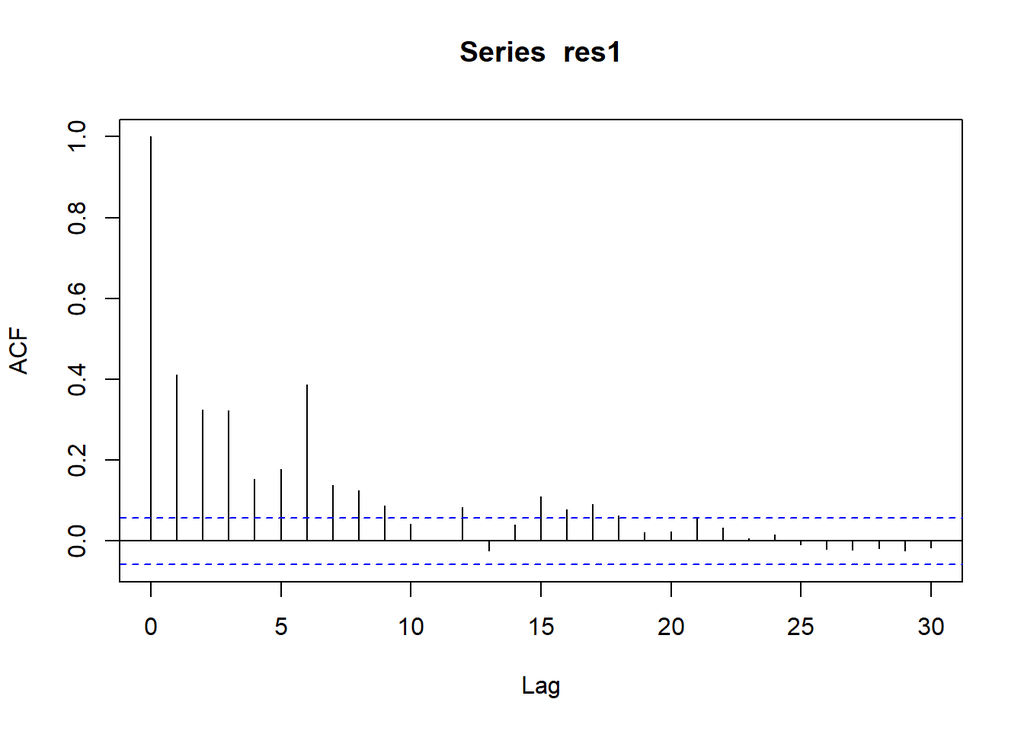

```r
# mod1:
res1 <- residuals(mod1)
acf1 <- acf(res1, type = "correlation")
```

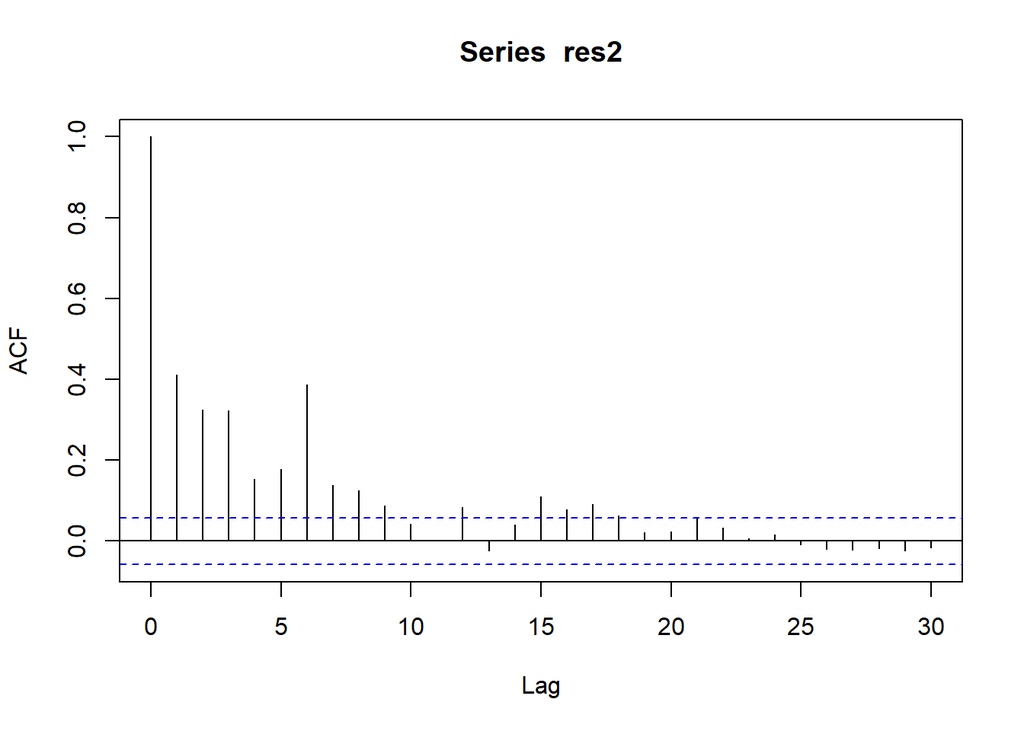

```r
acf1
acf1$acf[1:5]

# mod2:
res2 <- residuals(mod2)
acf2 <- acf(res2, type = "correlation")
```

[output not shown]

```r
acf2

# acf values:
acf1$acf[1:5]
acf2$acf[1:5]

# Check the AIC values:
AIC(mod1, mod2)

# Compare:
anova(mod1, mod2)
```

[output not shown]

ACF plots and values are identical. So this model hasn’t helped. Try some higher order models:

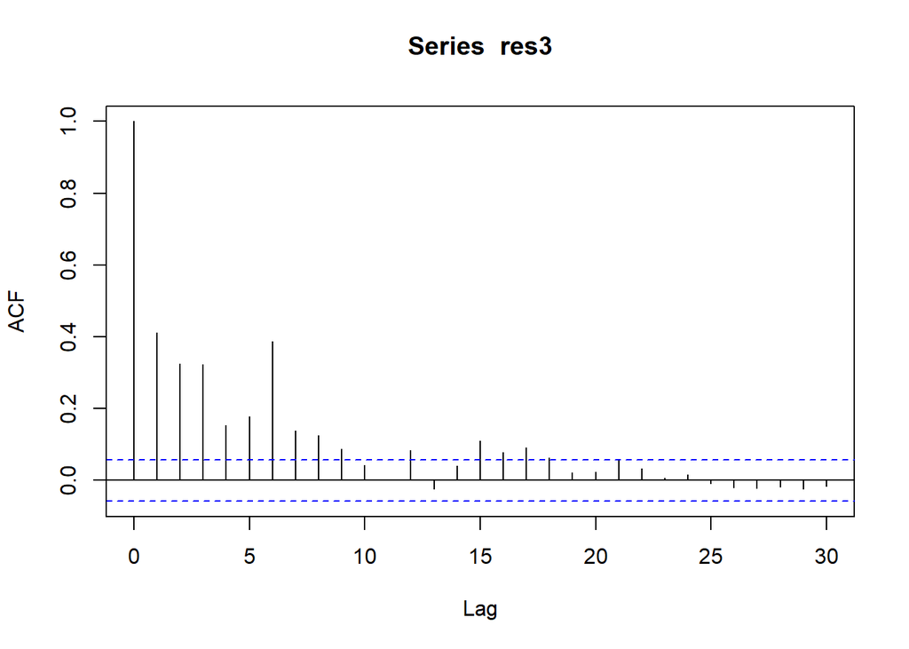

```r
mod3 <- gls(feat_1 ~ low_freq_ACI + low_freq_H + low_freq_M +
    low_freq_BI + high_freq_ACI + high_freq_BI + high_freq_H,
  correlation = corARMA(form = ~ time_cont | Reef, p = 2),
  data = df)

mod4 <- gls(feat_1 ~ low_freq_ACI + low_freq_H + low_freq_M +
    low_freq_BI + high_freq_ACI + high_freq_BI + high_freq_H,
  correlation = corARMA(form = ~ time_cont | Reef, p = 3),
  data = df)

# mod3:
res3 <- residuals(mod3)
acf3 <- acf(res3, type = "correlation")
```

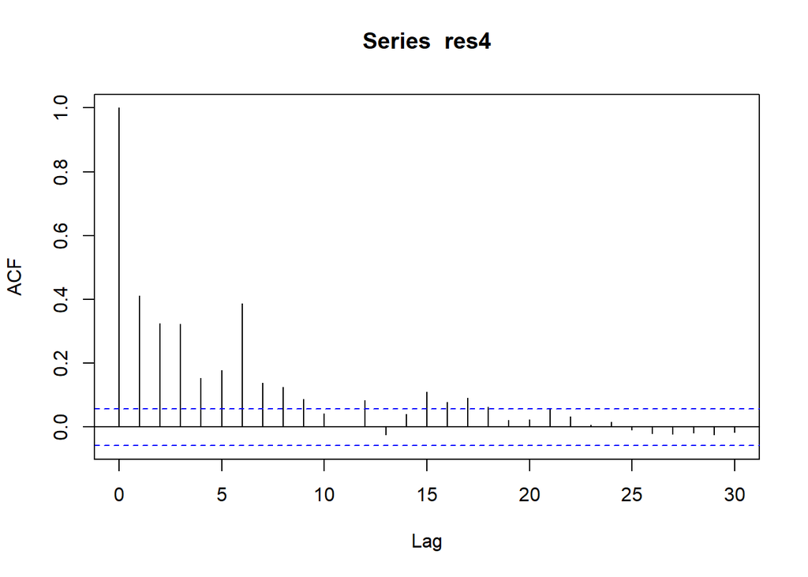

```r
# mod4:
res4 <- residuals(mod4)
acf4 <- acf(res4, type = "correlation")
```

```r
acf3$acf[1:5]
acf4$acf[1:5]
```

[output not shown]

Compare models:

```r
# acf values:
acf1$acf[1:5]
acf2$acf[1:5]
acf3$acf[1:5]
acf4$acf[1:5]

# AIC:
AIC(mod1, mod2, mod3, mod4)

# anova:
anova(mod1, mod4)
```

[output not shown]

**No statistical difference or improvement. The correlation term is not taking account of the TA**

### What does this mean?

A 3rd order correlation term for this sampling intensity means that the residual for each recording *cannot be explained by the 3 residuals before it*.

This could be because it’s really 24 hour cycles that matter, rather than a linear dependence on the past three hours. Tricky…

### Thoughts:

- With this subsampling regime the ACF values are lower. Perhaps it’s ok?
- Is there some other way to account for time?
- Is it possible that the acoustic indices simply *cannot explain* the variance in the deep learnt features that exhibit temporal dependence? That the temporal dependence is unrelated to soundscape charcteristics captured by the indices so whatever model we fit will make no difference. THis is plausible as the DL features are very likely to be detecting subtle things (e.g. species specific calls) that indices would miss.